# Kokteilakeppni 4. feb

# Hello kids

Ég hef haft óttalega lítið að gera seinustu daga meðan Harpa hefur verið að læra svona mikið og ég ákvað að henda í okkur smá *statistical analysis* af kokteilakeppninni okkar. *Af hverju?* you might ask… uhhhhh I dunno, github pages er cool og ég hef verið að læra R. Sue me. Also sorry að þessi síða lúkkar eins og HTML skólaproject frá 1999, svo lúkkar bara R markdown.

Ef þið viljið sjá datað hef ég hent því [hingað](https://docs.google.com/spreadsheets/d/1W29bIe_DUZgTCk9h8yACCU380T6xmR7NblG0IQF-tH8/edit?usp=sharing). Note að hver dálkur sýnir hvað þið fenguð í stig, eftir dómurum, sem er öfugt við það sem við skrifuðum á blöðin. Svo er ein röðin tóm í hverju sheet af því að þið gáfuð ykkur ekki sjálfum stig lol.

Ok kids byrjum á því að skoða öll stigin

Agla

| Dómari | Bragð | Look | Framsetning |
| --- | --- | --- | --- |
| Trausti | 4 | 4 | 4 |
| Hjalti | 3 | 4 | 4 |
| Jónas | 3 | 3 | 4 |
| Harpa | 3 | 3 | 3 |
| Kata | 4 | 5 | 5 |

Trausti

| Dómari | Bragð | Look | Framsetning |
| --- | --- | --- | --- |
| Agla | 2 | 4 | 3 |
| Hjalti | 4 | 4 | 4 |
| Jónas | 4 | 5 | 4 |
| Harpa | 4 | 4 | 3 |
| Kata | 2 | 5 | 5 |

Hjalti

| Dómari | Bragð | Look | Framsetning |
| --- | --- | --- | --- |
| Agla | 3 | 4 | 4 |
| Trausti | 4 | 5 | 5 |
| Jónas | 4 | 5 | 5 |
| Harpa | 3 | 4 | 4 |
| Kata | 5 | 4 | 5 |

Jónas

| Dómari | Bragð | Look | Framsetning |
| --- | --- | --- | --- |
| Agla | 5 | 4 | 4 |
| Trausti | 5 | 5 | 5 |
| Hjalti | 4 | 5 | 4 |
| Harpa | 5 | 5 | 4 |
| Kata | 3 | 5 | 5 |

Harpa

| Dómari | Bragð | Look | Framsetning |
| --- | --- | --- | --- |
| Agla | 4 | 4.0 | 4 |
| Trausti | 4 | 4.0 | 5 |
| Hjalti | 3 | 4.0 | 4 |
| Jónas | 3 | 4.5 | 4 |
| Kata | 3 | 4.0 | 5 |

Kata

| Dómari | Bragð | Look | Framsetning |
| --- | --- | --- | --- |
| Agla | 4 | 4 | 4 |
| Trausti | 4 | 5 | 4 |
| Hjalti | 4 | 5 | 4 |
| Jónas | 5 | 4 | 3 |
| Harpa | 5 | 4 | 3 |

*“Næs, næs, ok, það væri samt fucking hellað að geta séð þetta myndrænt”*

Bro say less

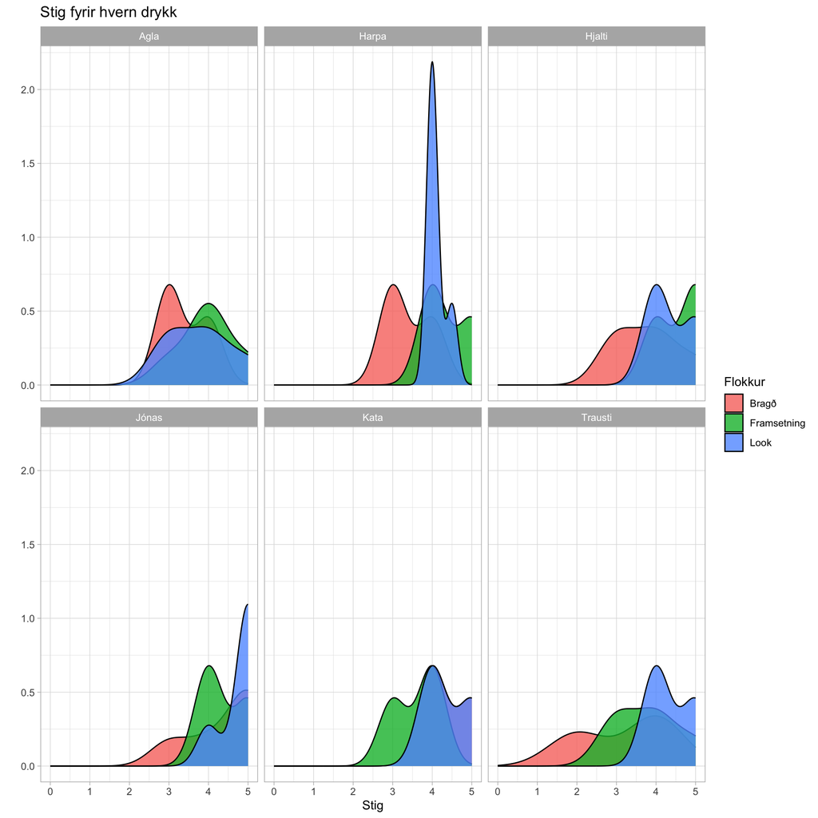

Stay updated fyrir meira content, eins og winner overall, winner í hverjum flokki, breakdown af hversu mikil stig þið gáfuð + the dreaded *Simon Cowell* fyrir fæst stig gefn